# Dream Home/Investment

Jisha

February 27, 2018

# Introduction

#American Dream Home

For many Americans homeownership is part of achieving their personal ‘American Dream’. Most Millennial renters aged 18-34 (89%) plan to buy a home one day - more than any other generation. But what does this dream home look like? And where is located? What amenities do people dream of most? For most people, a house is the biggest purchase they will make in their lives, one they will pay off for years, even decades, to come. Based on the type of homes people prefer and their priorities in amenities available in those homes answer the questions of new home buyers, sellers, remodelers and builders to make better decisions.

# Data

```r
#install.packages("plyr")
#install.packages("dplyr")
#install.packages("tidyr")
#install.packages("ggplot2")
#install.packages("scales")
#install.packages("graphics")
#install.packages("caret")

library(plyr)

library(dplyr)
library(magrittr)
library(stringr)
library(tidyr)
library(ggplot2)
library(scales)
library(graphics)
library(caret)
```

# Convert to local dataframe

```r
homedf <- read.csv("C:/springboard_capstone_project/final_project/home_poject_data/train.csv", header = TRUE)
homedf <- read.csv("C:/springboard_capstone_project/final_project/home_poject_data/train.csv",stringsAsFactors = FALSE)
homedf <- as.data.frame(homedf)
homedf <- tbl_df(homedf)
glimpse(homedf)
```

```
## Observations: 1,460
## Variables: 81
## $ Id            <int> 1, 2, 3, 4, 5, 6, 7, 8, 9, 10, 11, 12, 13, 14, 1...
## $ MSSubClass    <int> 60, 20, 60, 70, 60, 50, 20, 60, 50, 190, 20, 60,...
## $ MSZoning      <chr> "RL", "RL", "RL", "RL", "RL", "RL", "RL", "RL", ...
## $ LotFrontage   <int> 65, 80, 68, 60, 84, 85, 75, NA, 51, 50, 70, 85, ...
## $ LotArea       <int> 8450, 9600, 11250, 9550, 14260, 14115, 10084, 10...
## $ Street        <chr> "Pave", "Pave", "Pave", "Pave", "Pave", "Pave", ...
## $ Alley         <chr> NA, NA, NA, NA, NA, NA, NA, NA, NA, NA, NA, NA, ...
## $ LotShape      <chr> "Reg", "Reg", "IR1", "IR1", "IR1", "IR1", "Reg",...
## $ LandContour   <chr> "Lvl", "Lvl", "Lvl", "Lvl", "Lvl", "Lvl", "Lvl",...
## $ Utilities     <chr> "AllPub", "AllPub", "AllPub", "AllPub", "AllPub"...
## $ LotConfig     <chr> "Inside", "FR2", "Inside", "Corner", "FR2", "Ins...
## $ LandSlope     <chr> "Gtl", "Gtl", "Gtl", "Gtl", "Gtl", "Gtl", "Gtl",...
## $ Neighborhood  <chr> "CollgCr", "Veenker", "CollgCr", "Crawfor", "NoR...
```

[output cut: 68 more lines]

# Data Cleaning

#Finding the missing values in data

```r
any(is.na(homedf))
```

```
## [1] TRUE
```

# How many are there

```r
sum(is.na(homedf))
```

```
## [1] 6965
```

```r
# Return index of columns that have missing values
na.cols = which(colSums(is.na(homedf)) >0 )
#Break down missing values by variable
sort(colSums(sapply(homedf[na.cols], is.na)), decreasing = TRUE)
```

```
##       PoolQC  MiscFeature        Alley        Fence  FireplaceQu
##         1453         1406         1369         1179          690
##  LotFrontage   GarageType  GarageYrBlt GarageFinish   GarageQual
##          259           81           81           81           81
##   GarageCond BsmtExposure BsmtFinType2     BsmtQual     BsmtCond
##           81           38           38           37           37
## BsmtFinType1   MasVnrType   MasVnrArea   Electrical
##           37            8            8            1
```

```r
#homedf %>%
#dplyr:: select(everything(),- PoolQC)
```

Alley have NA encoded as a level to specify No Alley Access.It’s not “missing” values.There are 1369 missing values in Alley.Coding the NAs to No Alley, fixes all these missing values.

```r
# Changing NA to  "No Alley'

homedf$Alley[is.na(homedf$Alley)]<- "No Alley"
```

```r
table(homedf$Alley)
```

```
##
##     Grvl No Alley     Pave
##       50     1369       41
```

690 FireplaceQu is missing. Fireplace column shows the range of fire places from 0 to 3.Assuming 690 homes doesn’t have a fireplace change the ‘NA’ to ‘No fireplace’.

```r
table(homedf$Fireplaces)
```

```
##
##   0   1   2   3
## 690 650 115   5
```

```r
homedf$FireplaceQu[is.na(homedf$FireplaceQu)]<- "No Fireplace"
```

```r
table(homedf$FireplaceQu)
```

```
##
##           Ex           Fa           Gd No Fireplace           Po
##           24           33          380          690           20
##           TA
##          313
```

1179 missing values in Fence. Changing the NA’s to “No Fence”

```r
homedf$Fence[is.na(homedf$Fence)]<- "No Fence"
```

```r
table(homedf$Fence)
```

```
##
##    GdPrv     GdWo    MnPrv     MnWw No Fence
##       59       54      157       11     1179
```

259 values are missing in LotFrontage.There is no single variable in the dataset that gives a reason why these values are missing. We make the assumption that the lot frontage for a given house is fairly similar to the other properties.

```r
# Populating the NA's with the mean of lot frontage
lf.mean <- mean(homedf$LotFrontage, na.rm=TRUE)
homedf$LotFrontage[is.na(homedf$LotFrontage)] = lf.mean
lf.mean
```

```
## [1] 70.04996
```

5 Garage variables are missing 81 values.Checking the variables ‘GarageCars’ and ‘GarageArea’ gives the idea there is no garage built with the home .So the missing values are ‘none’.

```r
# Changing NA's in garage variable to none
homedf$GarageType[is.na(homedf$GarageType)]<- "None"
homedf$GarageFinish[is.na(homedf$GarageFinish)]<- "None"
homedf$GarageQual[is.na(homedf$GarageQual)]<- "None"
homedf$GarageCond[is.na(homedf$GarageCond)]<- "None"
```

```r
# Fill in Garage year Built
homedf$GarageYrBlt[is.na(homedf$GarageYrBlt)]<- "0"
```

Missing values in BsmtExposure,BsmtFinType1,BsmtFinType2,BsmtQual,BsmtCond is related with Basement sqrft 0.The missing values shows there is no basement.

```r
# Changing the Na's in Bsmt features with "No Basement"
homedf$BsmtExposure[is.na(homedf$BsmtExposure)]<- "No Basement"
homedf$BsmtFinType2[is.na(homedf$BsmtFinType2)]<- "No Basement"
homedf$BsmtQual[is.na(homedf$BsmtQual)]<- "No Basement"
homedf$BsmtCond[is.na(homedf$BsmtCond)]<- "No Basement"
homedf$BsmtFinType1[is.na(homedf$BsmtFinType1)]<- "No Basement"
```

Changing the missing values in MasVnrType And MasVnrArea wih ‘None’ and ‘0’.

```r
homedf$MasVnrType[is.na(homedf$MasVnrType)]<- "None"
homedf$MasVnrArea[is.na(homedf$MasVnrArea)]<- "0"
any(is.na(homedf$MasVnrType))
```

```
## [1] FALSE
```

```r
any(is.na(homedf$MasVnrArea))
```

```
## [1] FALSE
```

Fill in the electrical value with ‘None’

```r
homedf$Electrical[is.na(homedf$Electrical)]<- "None"
```

# New variables

combine the basement and ground level area squarefeet “TotalLivingAreaSF”

```r
homedf %>% mutate( TotalLivingAreaSF = GrLivArea + BsmtFinSF1 + BsmtFinSF2)
```

```
## # A tibble: 1,460 x 82
##       Id MSSu~ MSZo~ LotF~ LotA~ Stre~ Alley LotS~ Land~ Util~ LotC~ Land~
##    <int> <int> <chr> <dbl> <int> <chr> <chr> <chr> <chr> <chr> <chr> <chr>
##  1     1    60 RL     65.0  8450 Pave  No A~ Reg   Lvl   AllP~ Insi~ Gtl
##  2     2    20 RL     80.0  9600 Pave  No A~ Reg   Lvl   AllP~ FR2   Gtl
##  3     3    60 RL     68.0 11250 Pave  No A~ IR1   Lvl   AllP~ Insi~ Gtl
##  4     4    70 RL     60.0  9550 Pave  No A~ IR1   Lvl   AllP~ Corn~ Gtl
##  5     5    60 RL     84.0 14260 Pave  No A~ IR1   Lvl   AllP~ FR2   Gtl
##  6     6    50 RL     85.0 14115 Pave  No A~ IR1   Lvl   AllP~ Insi~ Gtl
##  7     7    20 RL     75.0 10084 Pave  No A~ Reg   Lvl   AllP~ Insi~ Gtl
##  8     8    60 RL     70.0 10382 Pave  No A~ IR1   Lvl   AllP~ Corn~ Gtl
##  9     9    50 RM     51.0  6120 Pave  No A~ Reg   Lvl   AllP~ Insi~ Gtl
## 10    10   190 RL     50.0  7420 Pave  No A~ Reg   Lvl   AllP~ Corn~ Gtl
## # ... with 1,450 more rows, and 70 more variables: Neighborhood <chr>,
## #   Condition1 <chr>, Condition2 <chr>, BldgType <chr>, HouseStyle <chr>,
## #   OverallQual <int>, OverallCond <int>, YearBuilt <int>, YearRemodAdd
## #   <int>, RoofStyle <chr>, RoofMatl <chr>, Exterior1st <chr>, Exterior2nd
## #   <chr>, MasVnrType <chr>, MasVnrArea <chr>, ExterQual <chr>, ExterCond
## #   <chr>, Foundation <chr>, BsmtQual <chr>, BsmtCond <chr>, BsmtExposure
## #   <chr>, BsmtFinType1 <chr>, BsmtFinSF1 <int>, BsmtFinType2 <chr>,
## #   BsmtFinSF2 <int>, BsmtUnfSF <int>, TotalBsmtSF <int>, Heating <chr>,
## #   HeatingQC <chr>, CentralAir <chr>, Electrical <chr>, X1stFlrSF <int>,
## #   X2ndFlrSF <int>, LowQualFinSF <int>, GrLivArea <int>, BsmtFullBath
## #   <int>, BsmtHalfBath <int>, FullBath <int>, HalfBath <int>,
## #   BedroomAbvGr <int>, KitchenAbvGr <int>, KitchenQual <chr>,
## #   TotRmsAbvGrd <int>, Functional <chr>, Fireplaces <int>, FireplaceQu
## #   <chr>, GarageType <chr>, GarageYrBlt <chr>, GarageFinish <chr>,
## #   GarageCars <int>, GarageArea <int>, GarageQual <chr>, GarageCond
## #   <chr>, PavedDrive <chr>, WoodDeckSF <int>, OpenPorchSF <int>,
## #   EnclosedPorch <int>, X3SsnPorch <int>, ScreenPorch <int>, PoolArea
## #   <int>, PoolQC <chr>, Fence <chr>, MiscFeature <chr>, MiscVal <int>,
## #   MoSold <int>, YrSold <int>, SaleType <chr>, SaleCondition <chr>,
## #   SalePrice <int>, TotalLivingAreaSF <int>
```

```r
 summary(homedf$TotalLivingAreaSF)
```

```
## Length  Class   Mode
##      0   NULL   NULL
```

```r
#Create new column total number of bathrooms in ground level & basement
homedf %>% mutate( TotNoBath = FullBath + HalfBath ,TotNoBsmtBath = BsmtFullBath +
BsmtHalfBath )
```

```
## # A tibble: 1,460 x 83
##       Id MSSu~ MSZo~ LotF~ LotA~ Stre~ Alley LotS~ Land~ Util~ LotC~ Land~
##    <int> <int> <chr> <dbl> <int> <chr> <chr> <chr> <chr> <chr> <chr> <chr>
##  1     1    60 RL     65.0  8450 Pave  No A~ Reg   Lvl   AllP~ Insi~ Gtl
##  2     2    20 RL     80.0  9600 Pave  No A~ Reg   Lvl   AllP~ FR2   Gtl
##  3     3    60 RL     68.0 11250 Pave  No A~ IR1   Lvl   AllP~ Insi~ Gtl
##  4     4    70 RL     60.0  9550 Pave  No A~ IR1   Lvl   AllP~ Corn~ Gtl
##  5     5    60 RL     84.0 14260 Pave  No A~ IR1   Lvl   AllP~ FR2   Gtl
##  6     6    50 RL     85.0 14115 Pave  No A~ IR1   Lvl   AllP~ Insi~ Gtl
##  7     7    20 RL     75.0 10084 Pave  No A~ Reg   Lvl   AllP~ Insi~ Gtl
##  8     8    60 RL     70.0 10382 Pave  No A~ IR1   Lvl   AllP~ Corn~ Gtl
##  9     9    50 RM     51.0  6120 Pave  No A~ Reg   Lvl   AllP~ Insi~ Gtl
## 10    10   190 RL     50.0  7420 Pave  No A~ Reg   Lvl   AllP~ Corn~ Gtl
## # ... with 1,450 more rows, and 71 more variables: Neighborhood <chr>,
## #   Condition1 <chr>, Condition2 <chr>, BldgType <chr>, HouseStyle <chr>,
## #   OverallQual <int>, OverallCond <int>, YearBuilt <int>, YearRemodAdd
## #   <int>, RoofStyle <chr>, RoofMatl <chr>, Exterior1st <chr>, Exterior2nd
## #   <chr>, MasVnrType <chr>, MasVnrArea <chr>, ExterQual <chr>, ExterCond
## #   <chr>, Foundation <chr>, BsmtQual <chr>, BsmtCond <chr>, BsmtExposure
## #   <chr>, BsmtFinType1 <chr>, BsmtFinSF1 <int>, BsmtFinType2 <chr>,
## #   BsmtFinSF2 <int>, BsmtUnfSF <int>, TotalBsmtSF <int>, Heating <chr>,
## #   HeatingQC <chr>, CentralAir <chr>, Electrical <chr>, X1stFlrSF <int>,
## #   X2ndFlrSF <int>, LowQualFinSF <int>, GrLivArea <int>, BsmtFullBath
## #   <int>, BsmtHalfBath <int>, FullBath <int>, HalfBath <int>,
## #   BedroomAbvGr <int>, KitchenAbvGr <int>, KitchenQual <chr>,
## #   TotRmsAbvGrd <int>, Functional <chr>, Fireplaces <int>, FireplaceQu
## #   <chr>, GarageType <chr>, GarageYrBlt <chr>, GarageFinish <chr>,
## #   GarageCars <int>, GarageArea <int>, GarageQual <chr>, GarageCond
## #   <chr>, PavedDrive <chr>, WoodDeckSF <int>, OpenPorchSF <int>,
## #   EnclosedPorch <int>, X3SsnPorch <int>, ScreenPorch <int>, PoolArea
## #   <int>, PoolQC <chr>, Fence <chr>, MiscFeature <chr>, MiscVal <int>,
## #   MoSold <int>, YrSold <int>, SaleType <chr>, SaleCondition <chr>,
## #   SalePrice <int>, TotNoBath <int>, TotNoBsmtBath <int>
```

```r
homedf
```

```
## # A tibble: 1,460 x 81
##       Id MSSu~ MSZo~ LotF~ LotA~ Stre~ Alley LotS~ Land~ Util~ LotC~ Land~
##    <int> <int> <chr> <dbl> <int> <chr> <chr> <chr> <chr> <chr> <chr> <chr>
##  1     1    60 RL     65.0  8450 Pave  No A~ Reg   Lvl   AllP~ Insi~ Gtl
##  2     2    20 RL     80.0  9600 Pave  No A~ Reg   Lvl   AllP~ FR2   Gtl
##  3     3    60 RL     68.0 11250 Pave  No A~ IR1   Lvl   AllP~ Insi~ Gtl
##  4     4    70 RL     60.0  9550 Pave  No A~ IR1   Lvl   AllP~ Corn~ Gtl
##  5     5    60 RL     84.0 14260 Pave  No A~ IR1   Lvl   AllP~ FR2   Gtl
##  6     6    50 RL     85.0 14115 Pave  No A~ IR1   Lvl   AllP~ Insi~ Gtl
##  7     7    20 RL     75.0 10084 Pave  No A~ Reg   Lvl   AllP~ Insi~ Gtl
##  8     8    60 RL     70.0 10382 Pave  No A~ IR1   Lvl   AllP~ Corn~ Gtl
##  9     9    50 RM     51.0  6120 Pave  No A~ Reg   Lvl   AllP~ Insi~ Gtl
## 10    10   190 RL     50.0  7420 Pave  No A~ Reg   Lvl   AllP~ Corn~ Gtl
## # ... with 1,450 more rows, and 69 more variables: Neighborhood <chr>,
## #   Condition1 <chr>, Condition2 <chr>, BldgType <chr>, HouseStyle <chr>,
## #   OverallQual <int>, OverallCond <int>, YearBuilt <int>, YearRemodAdd
## #   <int>, RoofStyle <chr>, RoofMatl <chr>, Exterior1st <chr>, Exterior2nd
## #   <chr>, MasVnrType <chr>, MasVnrArea <chr>, ExterQual <chr>, ExterCond
## #   <chr>, Foundation <chr>, BsmtQual <chr>, BsmtCond <chr>, BsmtExposure
## #   <chr>, BsmtFinType1 <chr>, BsmtFinSF1 <int>, BsmtFinType2 <chr>,
## #   BsmtFinSF2 <int>, BsmtUnfSF <int>, TotalBsmtSF <int>, Heating <chr>,
## #   HeatingQC <chr>, CentralAir <chr>, Electrical <chr>, X1stFlrSF <int>,
## #   X2ndFlrSF <int>, LowQualFinSF <int>, GrLivArea <int>, BsmtFullBath
## #   <int>, BsmtHalfBath <int>, FullBath <int>, HalfBath <int>,
## #   BedroomAbvGr <int>, KitchenAbvGr <int>, KitchenQual <chr>,
## #   TotRmsAbvGrd <int>, Functional <chr>, Fireplaces <int>, FireplaceQu
## #   <chr>, GarageType <chr>, GarageYrBlt <chr>, GarageFinish <chr>,
## #   GarageCars <int>, GarageArea <int>, GarageQual <chr>, GarageCond
## #   <chr>, PavedDrive <chr>, WoodDeckSF <int>, OpenPorchSF <int>,
## #   EnclosedPorch <int>, X3SsnPorch <int>, ScreenPorch <int>, PoolArea
## #   <int>, PoolQC <chr>, Fence <chr>, MiscFeature <chr>, MiscVal <int>,
## #   MoSold <int>, YrSold <int>, SaleType <chr>, SaleCondition <chr>,
## #   SalePrice <int>
```

```r
# New column Age of the House- "AgeOfHouse"
homedf %>% mutate(AgeOfHouse = YrSold- YearBuilt)
```

```
## # A tibble: 1,460 x 82
##       Id MSSu~ MSZo~ LotF~ LotA~ Stre~ Alley LotS~ Land~ Util~ LotC~ Land~
##    <int> <int> <chr> <dbl> <int> <chr> <chr> <chr> <chr> <chr> <chr> <chr>
##  1     1    60 RL     65.0  8450 Pave  No A~ Reg   Lvl   AllP~ Insi~ Gtl
##  2     2    20 RL     80.0  9600 Pave  No A~ Reg   Lvl   AllP~ FR2   Gtl
##  3     3    60 RL     68.0 11250 Pave  No A~ IR1   Lvl   AllP~ Insi~ Gtl
##  4     4    70 RL     60.0  9550 Pave  No A~ IR1   Lvl   AllP~ Corn~ Gtl
##  5     5    60 RL     84.0 14260 Pave  No A~ IR1   Lvl   AllP~ FR2   Gtl
##  6     6    50 RL     85.0 14115 Pave  No A~ IR1   Lvl   AllP~ Insi~ Gtl
##  7     7    20 RL     75.0 10084 Pave  No A~ Reg   Lvl   AllP~ Insi~ Gtl
##  8     8    60 RL     70.0 10382 Pave  No A~ IR1   Lvl   AllP~ Corn~ Gtl
##  9     9    50 RM     51.0  6120 Pave  No A~ Reg   Lvl   AllP~ Insi~ Gtl
## 10    10   190 RL     50.0  7420 Pave  No A~ Reg   Lvl   AllP~ Corn~ Gtl
## # ... with 1,450 more rows, and 70 more variables: Neighborhood <chr>,
## #   Condition1 <chr>, Condition2 <chr>, BldgType <chr>, HouseStyle <chr>,
## #   OverallQual <int>, OverallCond <int>, YearBuilt <int>, YearRemodAdd
## #   <int>, RoofStyle <chr>, RoofMatl <chr>, Exterior1st <chr>, Exterior2nd
## #   <chr>, MasVnrType <chr>, MasVnrArea <chr>, ExterQual <chr>, ExterCond
## #   <chr>, Foundation <chr>, BsmtQual <chr>, BsmtCond <chr>, BsmtExposure
## #   <chr>, BsmtFinType1 <chr>, BsmtFinSF1 <int>, BsmtFinType2 <chr>,
## #   BsmtFinSF2 <int>, BsmtUnfSF <int>, TotalBsmtSF <int>, Heating <chr>,
## #   HeatingQC <chr>, CentralAir <chr>, Electrical <chr>, X1stFlrSF <int>,
## #   X2ndFlrSF <int>, LowQualFinSF <int>, GrLivArea <int>, BsmtFullBath
## #   <int>, BsmtHalfBath <int>, FullBath <int>, HalfBath <int>,
## #   BedroomAbvGr <int>, KitchenAbvGr <int>, KitchenQual <chr>,
## #   TotRmsAbvGrd <int>, Functional <chr>, Fireplaces <int>, FireplaceQu
## #   <chr>, GarageType <chr>, GarageYrBlt <chr>, GarageFinish <chr>,
## #   GarageCars <int>, GarageArea <int>, GarageQual <chr>, GarageCond
## #   <chr>, PavedDrive <chr>, WoodDeckSF <int>, OpenPorchSF <int>,
## #   EnclosedPorch <int>, X3SsnPorch <int>, ScreenPorch <int>, PoolArea
## #   <int>, PoolQC <chr>, Fence <chr>, MiscFeature <chr>, MiscVal <int>,
## #   MoSold <int>, YrSold <int>, SaleType <chr>, SaleCondition <chr>,
## #   SalePrice <int>, AgeOfHouse <int>
```

```r
#summary( homedf$AgeOfHouse)
```

# Preliminary exploration of data

SalePrice graph

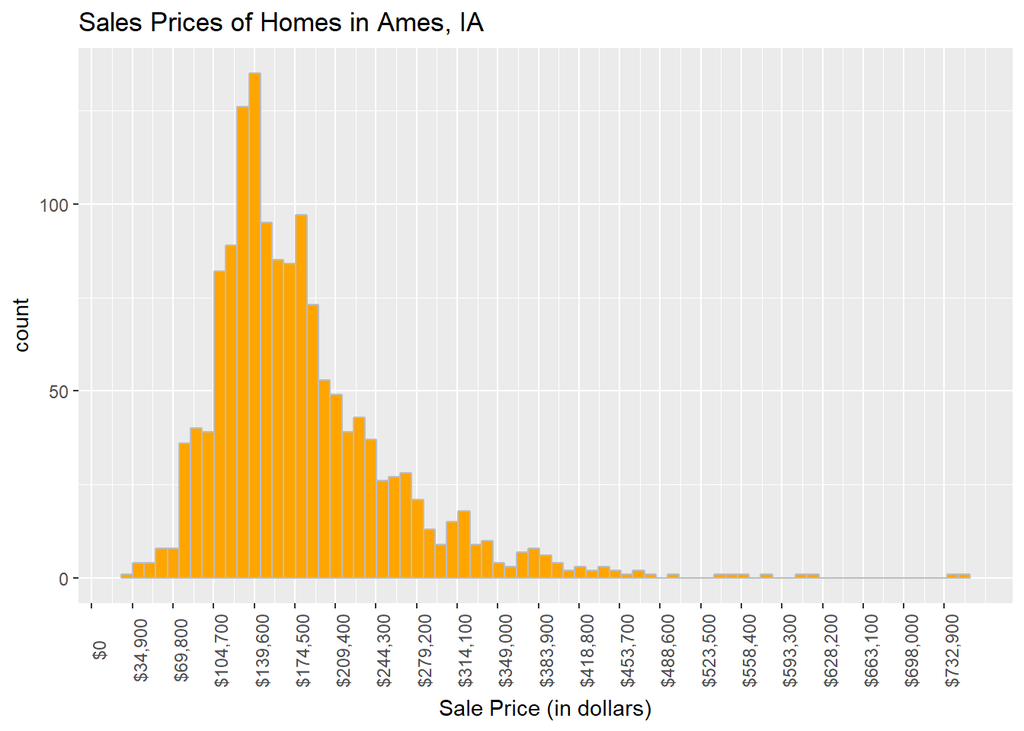

```r
#levels(homedf$SalePrice) <- (34900 :755000)

ggplot( homedf, aes(x = SalePrice)) +
  geom_histogram(binwidth=10000, fill = "orange", color = "grey") +
  scale_x_continuous(labels = dollar, breaks = seq(0, 755000, 34900)) +
  theme(axis.text.x = element_text(angle = 90))+
  labs(x = "Sale Price (in dollars)") +
  ggtitle("Sales Prices of Homes in Ames, IA")
```

# How expensive are houses?

```r
min(homedf$SalePrice, na.rm = T)
```

```
## [1] 34900
```

```r
max(homedf$SalePrice, na.rm = T)
```

```
## [1] 755000
```

```r
summary(homedf$SalePrice)
```

```
##    Min. 1st Qu.  Median    Mean 3rd Qu.    Max.
##   34900  129975  163000  180921  214000  755000
```

The sale price graph is positively skewed to the right with a good number of outliers. The cheapest house sold for $34,900 and the most expensive for $755,000 The average sales price is $180,921, while median is $163,000

# When were the houses built?

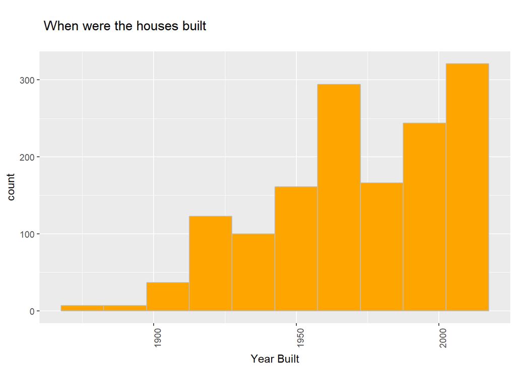

```r
ggplot(homedf, aes(x = YearBuilt)) +
  geom_histogram( binwidth = 15,fill = "orange",color = "grey" ) +

   theme(axis.text.x = element_text(angle = 90))+
  labs(x = "Year Built") +
   ggtitle("\n When were the houses built\n ")
```

```r
summary(homedf$YearBuilt)
```

```
##    Min. 1st Qu.  Median    Mean 3rd Qu.    Max.
##    1872    1954    1973    1971    2000    2010
```

```r
homedf %>% count(YrSold)
```

```
## # A tibble: 5 x 2
##   YrSold     n
##    <int> <int>
## 1   2006   314
## 2   2007   329
## 3   2008   304
## 4   2009   338
## 5   2010   175
```

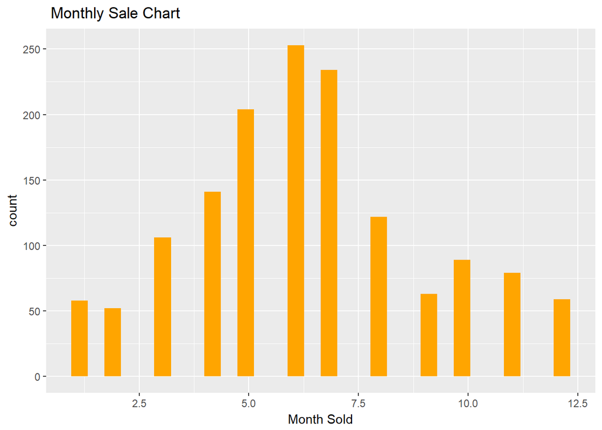

```r
ggplot(homedf, aes(x=MoSold ))+
  geom_histogram( fill ="orange" )+
  scale_x_continuous()+
  labs(x = "Month Sold")+
  ggtitle(" Monthly Sale Chart")
```

#The chart shows the home sales peak at May,June and July.

```r
homedf %>% count(MoSold)
```

```
## # A tibble: 12 x 2
##    MoSold     n
##     <int> <int>
##  1      1    58
##  2      2    52
##  3      3   106
##  4      4   141
##  5      5   204
##  6      6   253
##  7      7   234
##  8      8   122
##  9      9    63
## 10     10    89
## 11     11    79
## 12     12    59
```

# Which neighborhood are houses in?

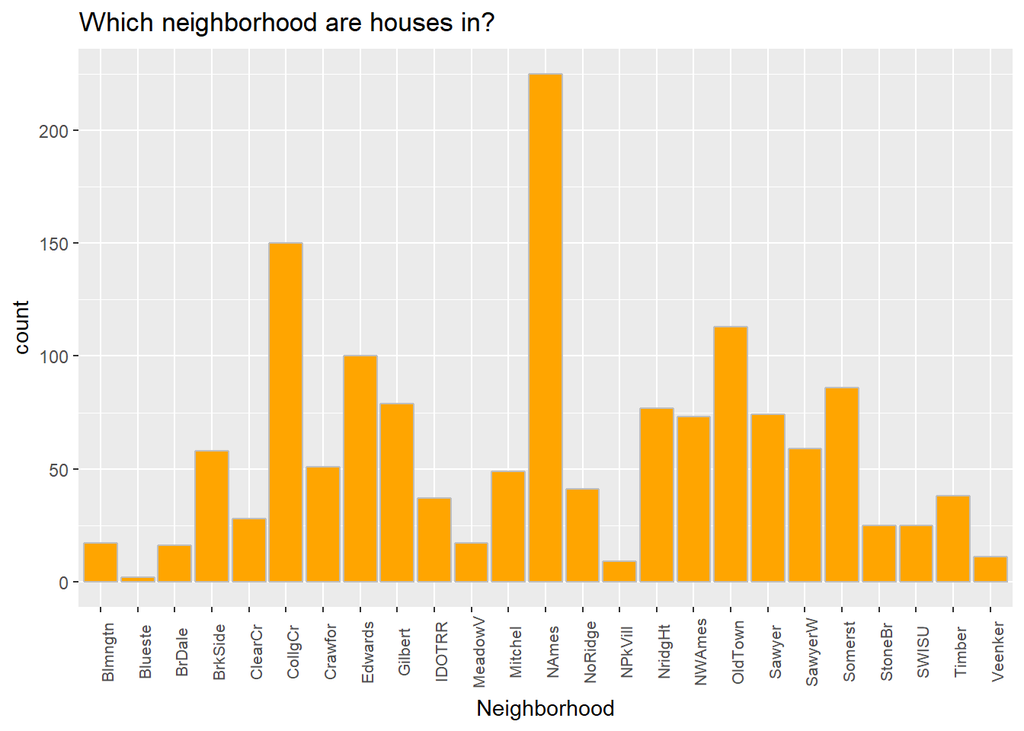

```r
ggplot(homedf, aes(Neighborhood))+
  geom_histogram( stat= 'count',binwidth=14, fill = "orange", color = "grey") +
   theme(axis.text.x = element_text(angle = 90, size = 8), legend.position = "none")+
    ggtitle("Which neighborhood are houses in?")
```

```r
homedf %>% count(homedf$Neighborhood)
```

```
## # A tibble: 25 x 2
##    `homedf$Neighborhood`     n
##    <chr>                 <int>
##  1 Blmngtn                  17
##  2 Blueste                   2
##  3 BrDale                   16
##  4 BrkSide                  58
##  5 ClearCr                  28
##  6 CollgCr                 150
##  7 Crawfor                  51
##  8 Edwards                 100
##  9 Gilbert                  79
## 10 IDOTRR                   37
## # ... with 15 more rows
```

Popular neigborhoods are North Ames,College Cir,Old Town and Edwards.

# Exploratory Data Analysis

# Boxplot of neighborhood and saleprice

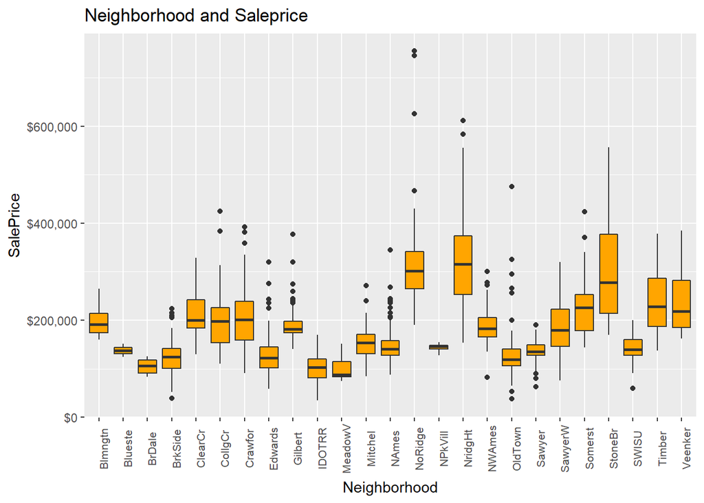

```r
ggplot(homedf, aes(x = Neighborhood, y = SalePrice)) +
  geom_boxplot(fill = "orange") +
  scale_y_continuous(labels = dollar)+
  theme(axis.text.x = element_text(angle = 90, size = 8), legend.position = "none") +
  ggtitle("Neighborhood and Saleprice")
```

How big are houses

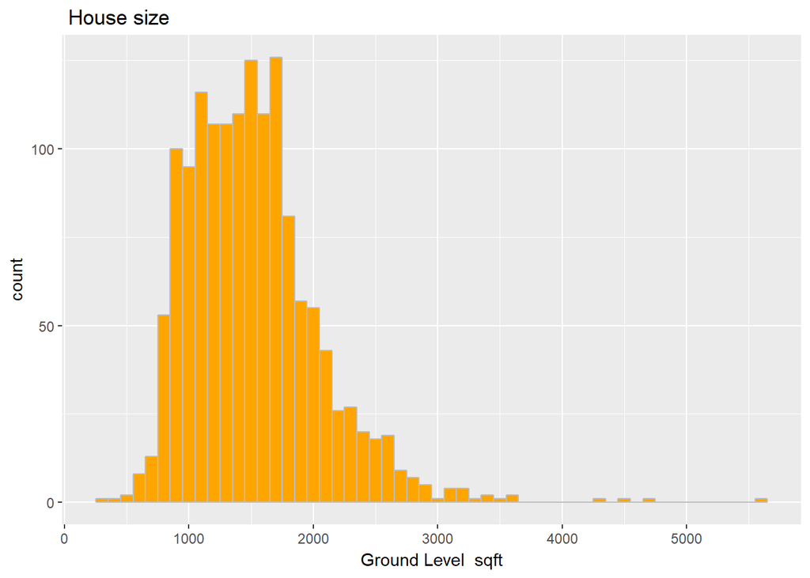

```r
ggplot(homedf, aes(x = GrLivArea)) +
  geom_histogram(binwidth = 100, fill = "orange",color = "grey" ) +
  labs(x = "Ground Level  sqft") +
  ggtitle(" House size ")
```

```r
summary(homedf$GrLivArea)
```

```
##    Min. 1st Qu.  Median    Mean 3rd Qu.    Max.
##     334    1130    1464    1515    1777    5642
```

The smallest house is 334 sqft and the biggest is 5642sqft

# How big are lots?

```r
summary(homedf$LotArea)
```

```
##    Min. 1st Qu.  Median    Mean 3rd Qu.    Max.
##    1300    7554    9478   10517   11602  215245
```

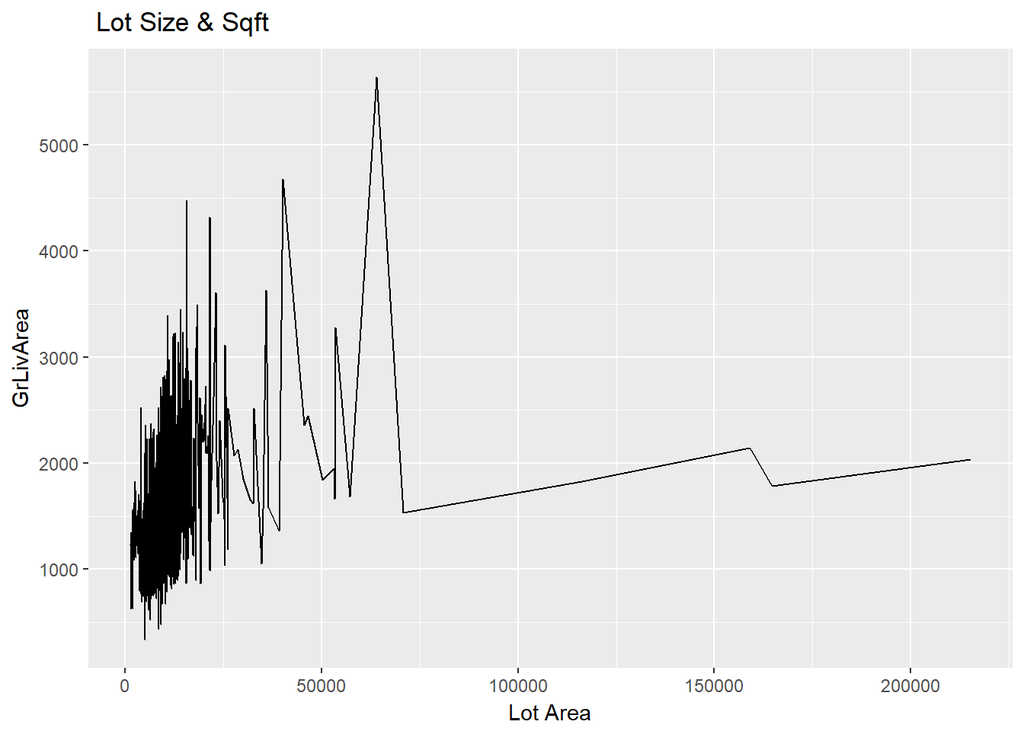

```r
ggplot(homedf, aes(x = LotArea , y = GrLivArea)) +
  geom_line() +
  labs(x = "Lot Area") +
  ggtitle(" Lot Size & Sqft ")
```

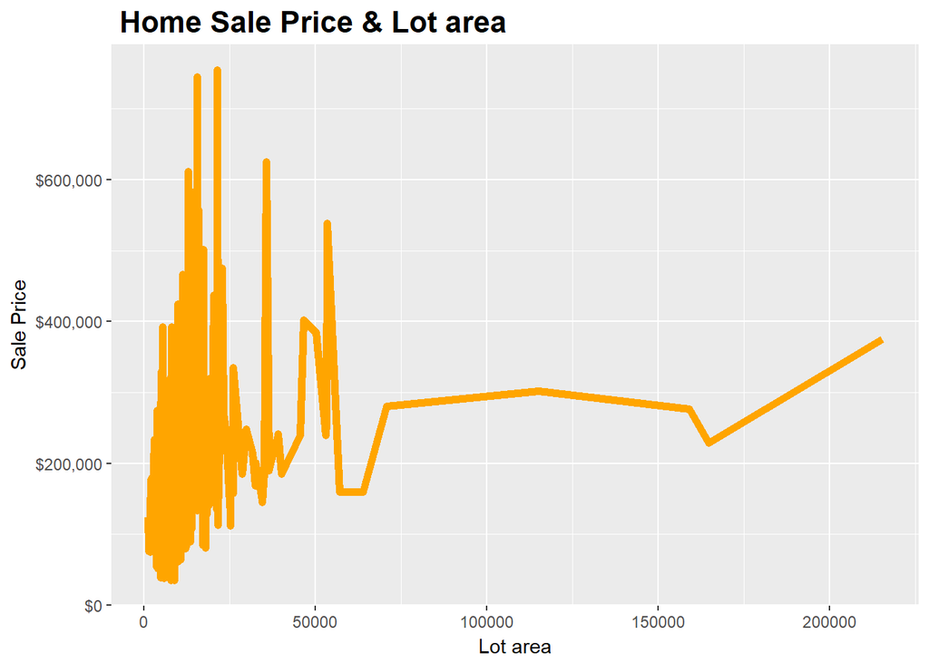

```r
ggplot(homedf, aes(LotArea, SalePrice)) +
  geom_line(color="orange", size=2) +
  scale_y_continuous("Sale Price", labels = dollar) +
  scale_x_continuous("Lot area") +
  ggtitle(" Home Sale Price & Lot area") +
  theme(plot.title = element_text(size = 16, face="bold"))
```

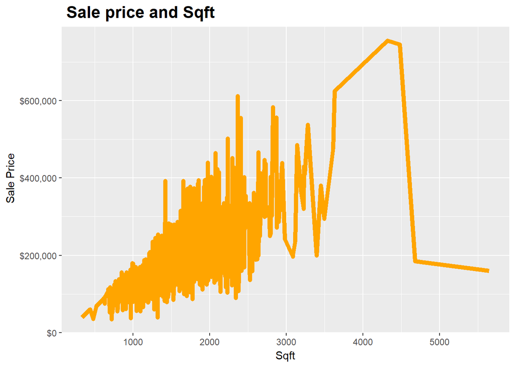

```r
ggplot(homedf, aes(GrLivArea, SalePrice)) +
  geom_line(color="Orange", size=2) +
  scale_y_continuous(" Sale Price", labels = dollar) +
  scale_x_continuous("Sqft") +
  ggtitle(" Sale price and Sqft") +
  theme(plot.title = element_text(size = 16, face="bold"))
```

```r
summary(homedf$LotArea)
```

```
##    Min. 1st Qu.  Median    Mean 3rd Qu.    Max.
##    1300    7554    9478   10517   11602  215245
```

```r
summary(homedf$GrLivArea)
```

```
##    Min. 1st Qu.  Median    Mean 3rd Qu.    Max.
##     334    1130    1464    1515    1777    5642
```

```r
summary(homedf$SalePrice)
```

```
##    Min. 1st Qu.  Median    Mean 3rd Qu.    Max.
##   34900  129975  163000  180921  214000  755000
```

# Dwelling Type

The MsSubclass variable specifies the type of dwelling involved in the sale. The variable is coded as an integer and has a key that can be found in the documentation. Numbers in the 20 to 85 range represent different traditional style homes and others represent duplexes or other split homes.

```r
table(homedf$MSSubClass)
```

```
##
##  20  30  40  45  50  60  70  75  80  85  90 120 160 180 190
## 536  69   4  12 144 299  60  16  58  20  52  87  63  10  30
```

# Zoning Classifications

```r
table(homedf$MSZoning)
```

```
##
## C (all)      FV      RH      RL      RM
##      10      65      16    1151     218
```

```r
# shorten to C
index <- which(homedf$MSZoning == "C (all)")
homedf[index, 'MSZoning'] <- "C"
table(homedf$MSZoning)
```

```
##
##    C   FV   RH   RL   RM
##   10   65   16 1151  218
```

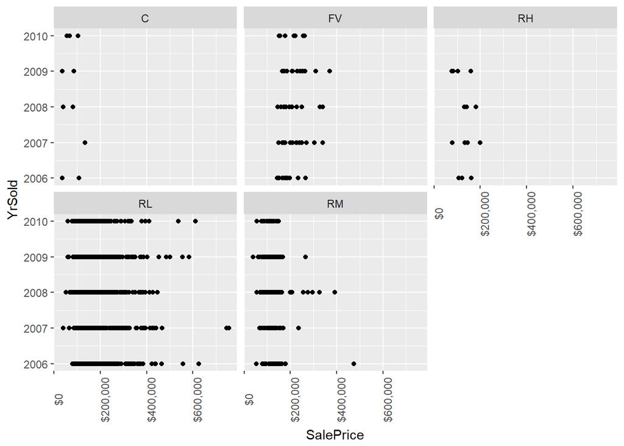

```r
ggplot(homedf, aes(SalePrice, YrSold)) +
  geom_point() +
  scale_x_continuous(labels = dollar)+
  theme(axis.text.x = element_text(angle = 90))+
  facet_wrap(~MSZoning)
```

The plots shows most sales happened at the lower density residential areas.

# Linear relation between Lot Frontage and Sale Price

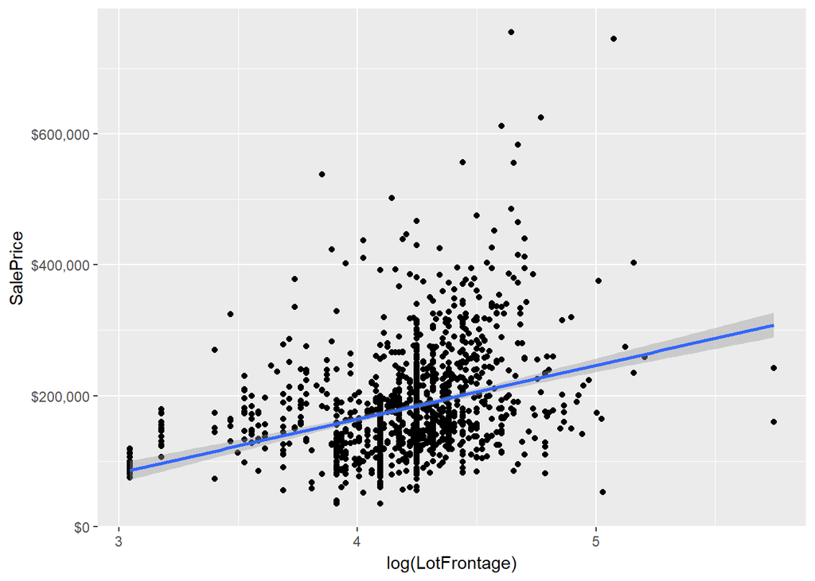

```r
ggplot(homedf, aes(x = log(LotFrontage), y = SalePrice)) +
  geom_point() +
   scale_y_continuous(labels = dollar)+
  geom_smooth(method = "lm")
```

Lot Area

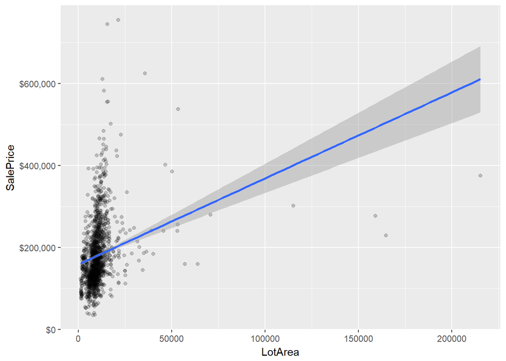

```r
# scatter plot vs sale price
ggplot(homedf, aes(x = LotArea, y = SalePrice)) +
  geom_point(alpha = 0.2) +
  geom_smooth(method = "lm") +
  scale_y_continuous(labels = dollar)
```

```r
summary(homedf$LotArea)
```

```
##    Min. 1st Qu.  Median    Mean 3rd Qu.    Max.
##    1300    7554    9478   10517   11602  215245
```

# In lot area

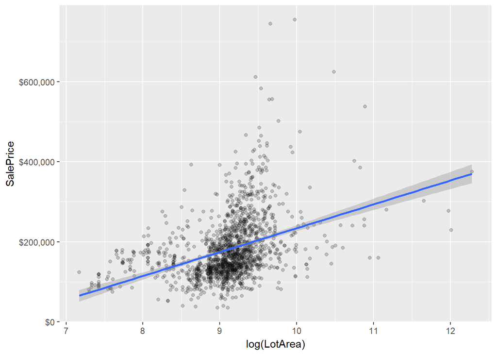

```r
ggplot(homedf, aes(x = log(LotArea), y = SalePrice)) +
  geom_point(alpha = 0.2) +
  geom_smooth(method = "lm") +
  scale_y_continuous(labels = dollar)
```

There seems to be some very high end outliers influencing the scatter plot of sale price and lot area-some lot areas are much larger than most. For this reason, we look at the natural log of lot area instead

# Street

```r
homedf$Street <-as.factor(homedf$Street)
summary(homedf$Street)
```

```
## Grvl Pave
##    6 1454
```

# LOt Shape

```r
table(homedf$LotShape)
```

```
##
## IR1 IR2 IR3 Reg
## 484  41  10 925
```

Lot shape: 484 lots are Slightly irregular,41 areModerately Irregular,10 are Irregular and 925 are Regular

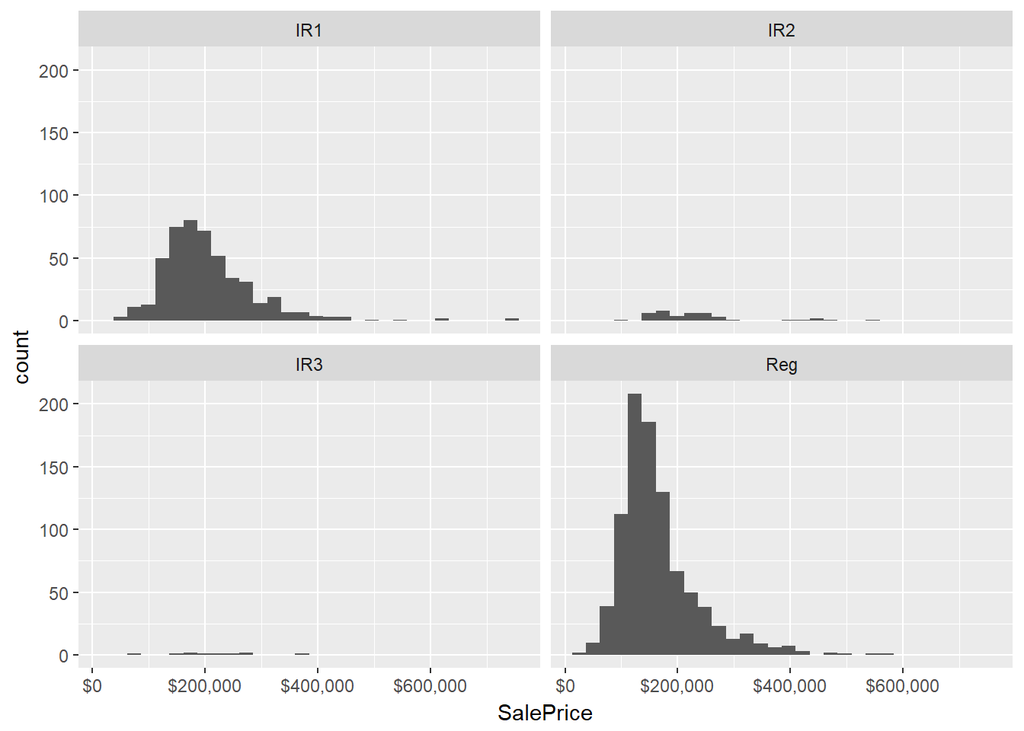

```r
ggplot(homedf,aes(x = SalePrice))+
  geom_histogram(biwidth = 0.7)+
  scale_x_continuous(labels = dollar)+
  facet_wrap(~ LotShape)
```

```r
homedf %>%
  group_by(LotShape) %>%
  dplyr::summarise(n = n(),
            mean_SalePrice = mean(SalePrice))
```

```
## # A tibble: 4 x 3
##   LotShape     n mean_SalePrice
##   <chr>    <int>          <dbl>
## 1 IR1        484         206102
## 2 IR2         41         239833
## 3 IR3         10         216036
## 4 Reg        925         164755
```

Mean sale price is high on lot shape moderately irregular and irregular.

# Land Contour

```r
table(homedf$LandContour)
```

```
##
##  Bnk  HLS  Low  Lvl
##   63   50   36 1311
```

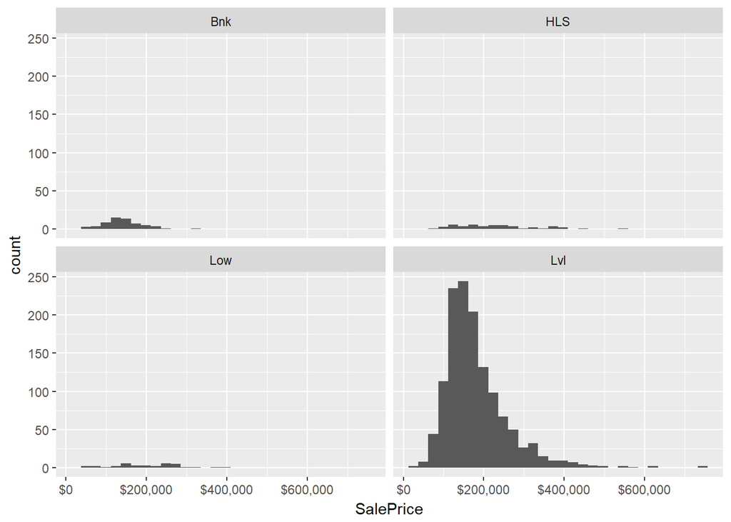

```r
 ggplot(homedf, aes(SalePrice)) +
  geom_histogram()+
   scale_x_continuous(labels = dollar)+
  facet_wrap(~LandContour)
```

```r
homedf %>%
  group_by(LandContour) %>%
  dplyr::summarise(n = n(),
            mean_SalePrice = mean(SalePrice))
```

```
## # A tibble: 4 x 3
##   LandContour     n mean_SalePrice
##   <chr>       <int>          <dbl>
## 1 Bnk            63         143104
## 2 HLS            50         231534
## 3 Low            36         203661
## 4 Lvl          1311         180184
```

# Utilities

```r
homedf %>%
  group_by(Utilities) %>%
  dplyr::summarise(n = n(),
            mean_SalePrice = mean(SalePrice))
```

```
## # A tibble: 2 x 3
##   Utilities     n mean_SalePrice
##   <chr>     <int>          <dbl>
## 1 AllPub     1459         180951
## 2 NoSeWa        1         137500
```

Except one utility variable got the same value.

```r
# Drop the Utility variable
homedf %>%
  dplyr::select(everything(), -Utilities)
```

```
## # A tibble: 1,460 x 80
##       Id MSSu~ MSZo~ LotF~ LotA~ Stre~ Alley LotS~ Land~ LotC~ Land~ Neig~
##    <int> <int> <chr> <dbl> <int> <fct> <chr> <chr> <chr> <chr> <chr> <chr>
##  1     1    60 RL     65.0  8450 Pave  No A~ Reg   Lvl   Insi~ Gtl   Coll~
##  2     2    20 RL     80.0  9600 Pave  No A~ Reg   Lvl   FR2   Gtl   Veen~
##  3     3    60 RL     68.0 11250 Pave  No A~ IR1   Lvl   Insi~ Gtl   Coll~
##  4     4    70 RL     60.0  9550 Pave  No A~ IR1   Lvl   Corn~ Gtl   Craw~
##  5     5    60 RL     84.0 14260 Pave  No A~ IR1   Lvl   FR2   Gtl   NoRi~
##  6     6    50 RL     85.0 14115 Pave  No A~ IR1   Lvl   Insi~ Gtl   Mitc~
##  7     7    20 RL     75.0 10084 Pave  No A~ Reg   Lvl   Insi~ Gtl   Some~
##  8     8    60 RL     70.0 10382 Pave  No A~ IR1   Lvl   Corn~ Gtl   NWAm~
##  9     9    50 RM     51.0  6120 Pave  No A~ Reg   Lvl   Insi~ Gtl   OldT~
## 10    10   190 RL     50.0  7420 Pave  No A~ Reg   Lvl   Corn~ Gtl   BrkS~
## # ... with 1,450 more rows, and 68 more variables: Condition1 <chr>,
## #   Condition2 <chr>, BldgType <chr>, HouseStyle <chr>, OverallQual <int>,
## #   OverallCond <int>, YearBuilt <int>, YearRemodAdd <int>, RoofStyle
## #   <chr>, RoofMatl <chr>, Exterior1st <chr>, Exterior2nd <chr>,
## #   MasVnrType <chr>, MasVnrArea <chr>, ExterQual <chr>, ExterCond <chr>,
## #   Foundation <chr>, BsmtQual <chr>, BsmtCond <chr>, BsmtExposure <chr>,
## #   BsmtFinType1 <chr>, BsmtFinSF1 <int>, BsmtFinType2 <chr>, BsmtFinSF2
## #   <int>, BsmtUnfSF <int>, TotalBsmtSF <int>, Heating <chr>, HeatingQC
## #   <chr>, CentralAir <chr>, Electrical <chr>, X1stFlrSF <int>, X2ndFlrSF
## #   <int>, LowQualFinSF <int>, GrLivArea <int>, BsmtFullBath <int>,
## #   BsmtHalfBath <int>, FullBath <int>, HalfBath <int>, BedroomAbvGr
## #   <int>, KitchenAbvGr <int>, KitchenQual <chr>, TotRmsAbvGrd <int>,
## #   Functional <chr>, Fireplaces <int>, FireplaceQu <chr>, GarageType
## #   <chr>, GarageYrBlt <chr>, GarageFinish <chr>, GarageCars <int>,
## #   GarageArea <int>, GarageQual <chr>, GarageCond <chr>, PavedDrive
## #   <chr>, WoodDeckSF <int>, OpenPorchSF <int>, EnclosedPorch <int>,
## #   X3SsnPorch <int>, ScreenPorch <int>, PoolArea <int>, PoolQC <chr>,
## #   Fence <chr>, MiscFeature <chr>, MiscVal <int>, MoSold <int>, YrSold
## #   <int>, SaleType <chr>, SaleCondition <chr>, SalePrice <int>
```

# Lot Configuration

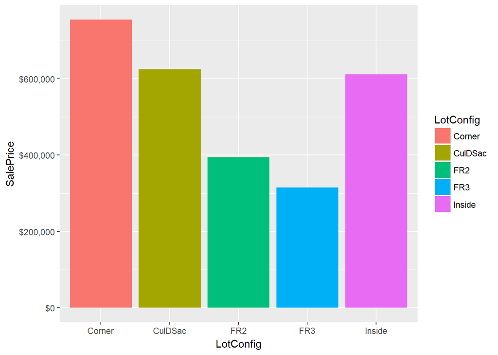

```r
ggplot(homedf, aes(fill=LotConfig, y=SalePrice, x=LotConfig)) +
geom_bar(position = "dodge", stat="identity")+
   scale_y_continuous(labels = dollar)
```

```r
table(homedf$LotConfig)
```

```
##
##  Corner CulDSac     FR2     FR3  Inside
##     263      94      47       4    1052
```

```r
homedf %>%
  group_by(LotConfig) %>%
  dplyr::summarise(n = n(),
            mean_SalePrice = mean(SalePrice))
```

```
## # A tibble: 5 x 3
##   LotConfig     n mean_SalePrice
##   <chr>     <int>          <dbl>
## 1 Corner      263         181623
## 2 CulDSac      94         223855
## 3 FR2          47         177935
## 4 FR3           4         208475
## 5 Inside     1052         176938
```

# Land Slope

```r
homedf %>%
  group_by(LandSlope) %>%
  dplyr::summarise(n = n(),
            mean_SalePrice = mean(SalePrice))
```

```
## # A tibble: 3 x 3
##   LandSlope     n mean_SalePrice
##   <chr>     <int>          <dbl>
## 1 Gtl        1382         179957
## 2 Mod          65         196734
## 3 Sev          13         204379
```

Sale price changes with the land slope level

# Quality ,Type and price

```r
homedf %>%
  group_by(BldgType) %>%
  dplyr::summarise(n = n(),
            mean_SalePrice = mean(SalePrice))
```

```
## # A tibble: 5 x 3
##   BldgType     n mean_SalePrice
##   <chr>    <int>          <dbl>
## 1 1Fam      1220         185764
## 2 2fmCon      31         128432
## 3 Duplex      52         133541
## 4 Twnhs       43         135912
## 5 TwnhsE     114         181959
```

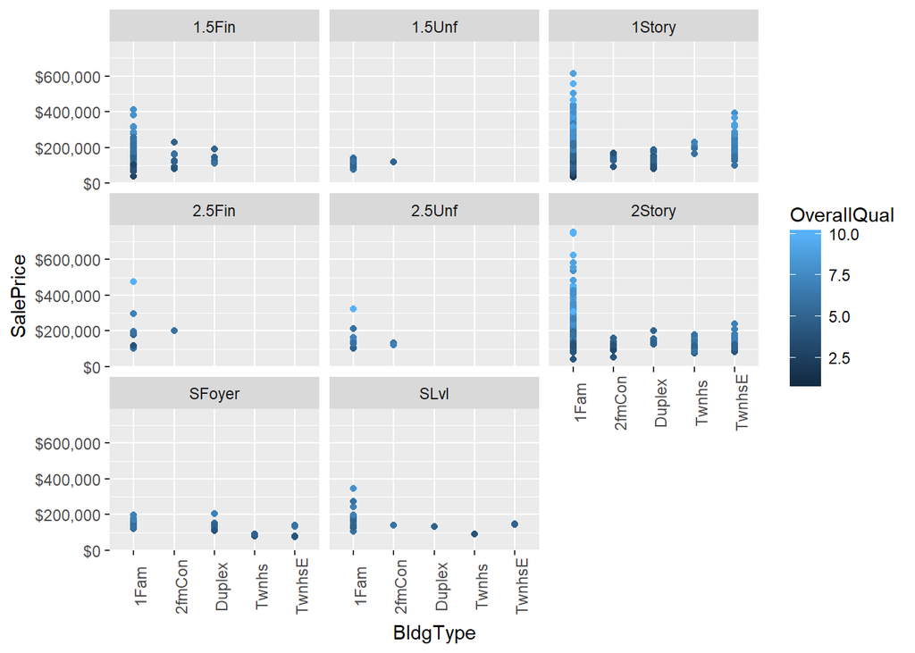

```r
ggplot(homedf, aes(x = BldgType, y = SalePrice, color = OverallQual)) + geom_point()+
   scale_y_continuous(labels = dollar)+
   theme(axis.text.x = element_text(angle = 90))+
facet_wrap(~HouseStyle)
```

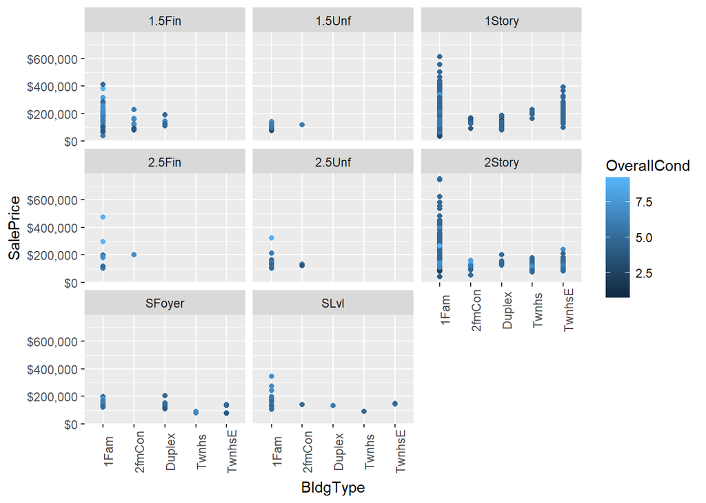

```r
ggplot(homedf, aes(x = BldgType, y = SalePrice, color = OverallCond)) + geom_point()+
   scale_y_continuous(labels = dollar)+
   theme(axis.text.x = element_text(angle = 90))+
facet_wrap(~HouseStyle)
```

Overall Quality of the home matters most.

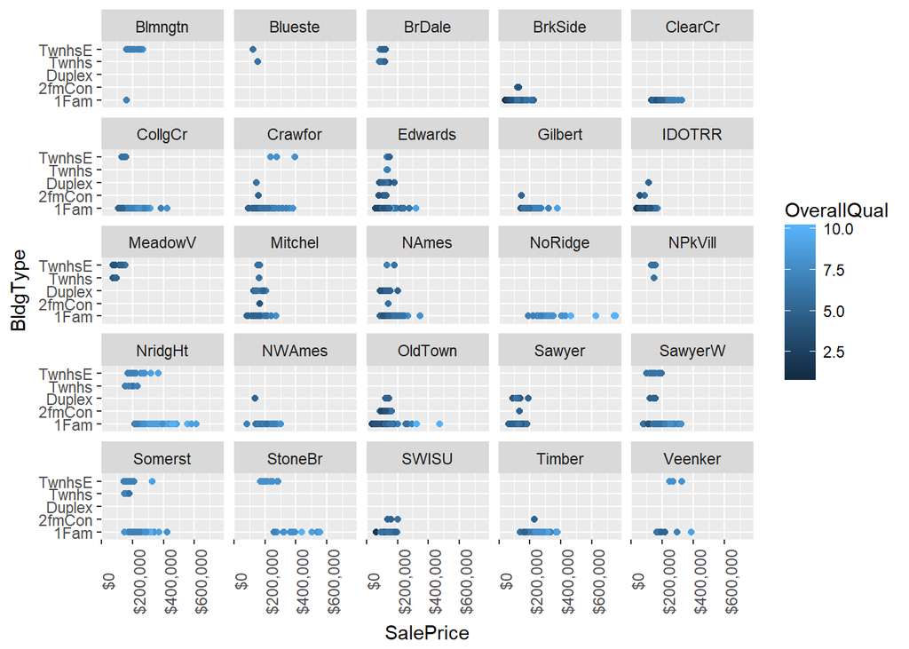

```r
ggplot(homedf, aes( x=SalePrice,y=BldgType,color=OverallQual)) +
    geom_point( stat="identity") +
   scale_x_continuous(labels = dollar)+
  theme(axis.text.x = element_text(angle = 90))+
    facet_wrap(~Neighborhood)
```

```r
homedf %>%
  group_by(Neighborhood) %>%
  dplyr::summarise(n = n(),
            mean_SalePrice = mean(SalePrice))
```

```
## # A tibble: 25 x 3
##    Neighborhood     n mean_SalePrice
##    <chr>        <int>          <dbl>
##  1 Blmngtn         17         194871
##  2 Blueste          2         137500
##  3 BrDale          16         104494
##  4 BrkSide         58         124834
##  5 ClearCr         28         212565
##  6 CollgCr        150         197966
##  7 Crawfor         51         210625
##  8 Edwards        100         128220
##  9 Gilbert         79         192855
## 10 IDOTRR          37         100124
## # ... with 15 more rows
```

Our popular neigborhoods(North Ames,College Cir,Old Town and Edwards) shows variety, affordability and overall quality of availability in homes.

```r
homedf %>%
  group_by(Condition1) %>%
  dplyr::summarise(n = n(),
            mean_SalePrice = mean(SalePrice))
```

```
## # A tibble: 9 x 3
##   Condition1     n mean_SalePrice
##   <chr>      <int>          <dbl>
## 1 Artery        48         135092
## 2 Feedr         81         142475
## 3 Norm        1260         184495
## 4 PosA           8         225875
## 5 PosN          19         215184
## 6 RRAe          11         138400
## 7 RRAn          26         184397
## 8 RRNe           2         190750
## 9 RRNn           5         212400
```

```r
homedf %>%
  group_by(Condition2) %>%
  dplyr::summarise(n = n(),
            mean_SalePrice = mean(SalePrice))
```

```
## # A tibble: 8 x 3
##   Condition2     n mean_SalePrice
##   <chr>      <int>          <dbl>
## 1 Artery         2         106500
## 2 Feedr          6         121167
## 3 Norm        1445         181169
## 4 PosA           1         325000
## 5 PosN           2         284875
## 6 RRAe           1         190000
## 7 RRAn           1         136905
## 8 RRNn           2          96750
```

# Year Built and Remodel

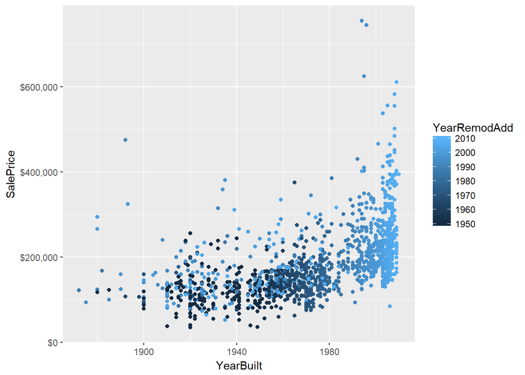

```r
 ggplot(homedf, aes(x = YearBuilt, y = SalePrice, color = YearRemodAdd)) + geom_point()+
   scale_y_continuous(labels = dollar)
```

Remodelling adds the value to the house

# Exterior

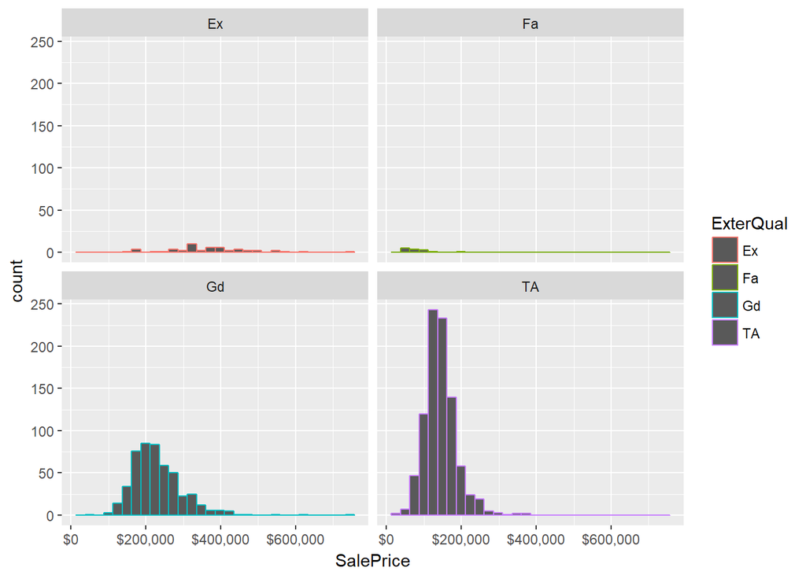

```r
ggplot(homedf,aes(x = SalePrice,color=ExterQual))+
  geom_histogram(biwidth = 1000)+
  scale_x_continuous(labels = dollar)+
  facet_wrap(~ExterQual)
```

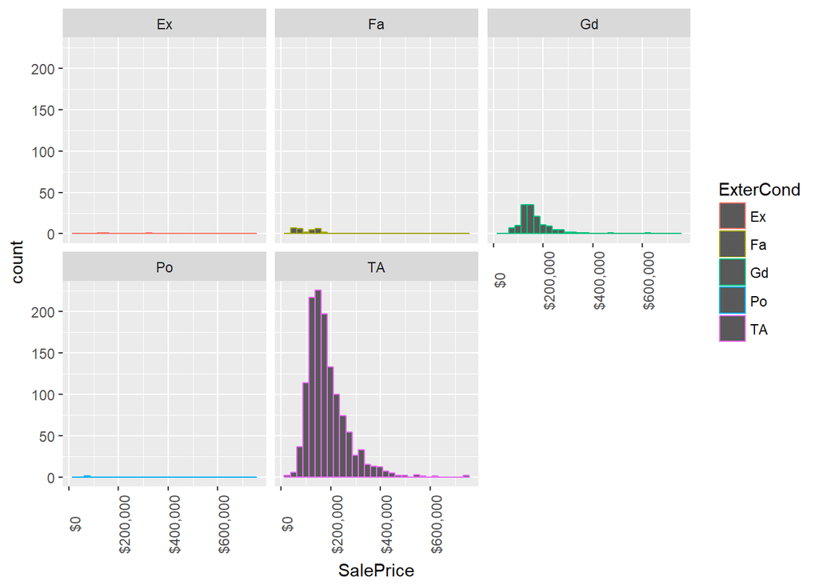

```r
ggplot(homedf,aes(x = SalePrice, color= ExterCond))+
  geom_histogram(biwidth = 1000)+
  scale_x_continuous(labels = dollar)+
   theme(axis.text.x = element_text(angle = 90))+
   facet_wrap(~ExterCond)
```

```r
table(homedf$ExterQual)
```

```
##
##  Ex  Fa  Gd  TA
##  52  14 488 906
```

```r
 table(homedf$ExterCond)
```

```
##
##   Ex   Fa   Gd   Po   TA
##    3   28  146    1 1282
```

# Basement

```r
homedf %>% count(homedf$BsmtQual,BsmtFullBath,BsmtHalfBath)
```

```
## # A tibble: 23 x 4
##    `homedf$BsmtQual` BsmtFullBath BsmtHalfBath     n
##    <chr>                    <int>        <int> <int>
##  1 Ex                           0            0    38
##  2 Ex                           0            1     2
##  3 Ex                           0            2     1
##  4 Ex                           1            0    76
##  5 Ex                           1            1     2
##  6 Ex                           2            0     2
##  7 Fa                           0            0    28
##  8 Fa                           0            1     1
##  9 Fa                           1            0     5
## 10 Fa                           1            1     1
## # ... with 13 more rows
```

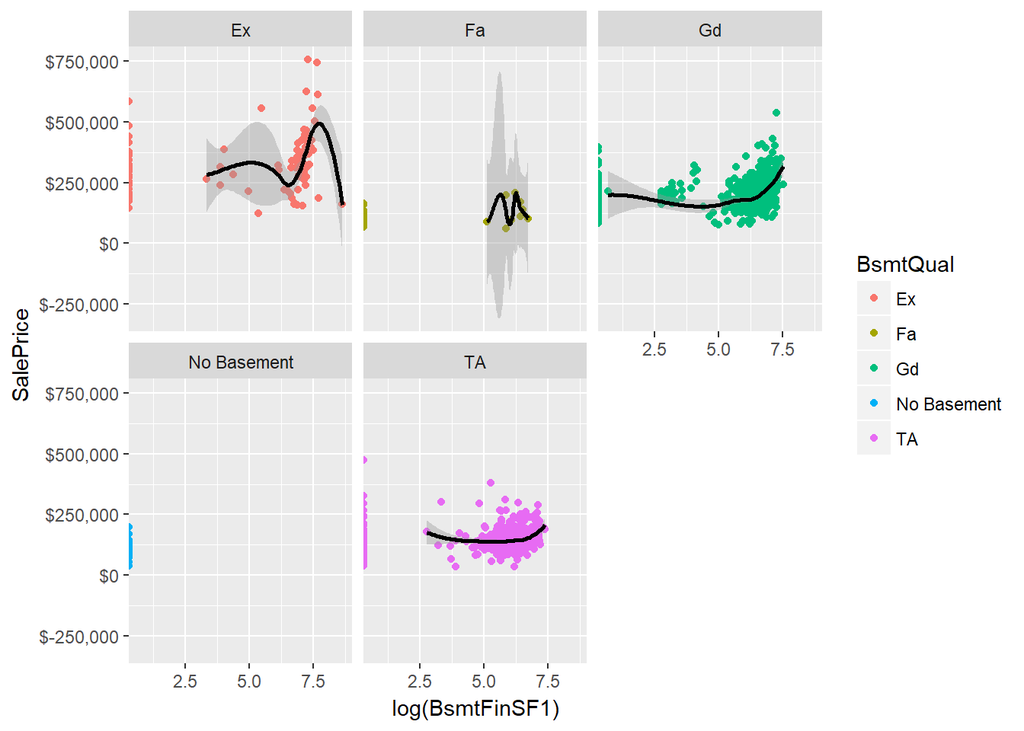

```r
 ggplot(homedf, aes(x = log(BsmtFinSF1), y = SalePrice, color = BsmtQual)) +
  geom_point()+
  stat_smooth(color='black')+
  scale_y_continuous(labels = dollar)+
  facet_wrap(~BsmtQual)
```

```r
table(homedf$BsmtQual)
```

```
##
##          Ex          Fa          Gd No Basement          TA
##         121          35         618          37         649
```

A bigger and good quality basement area with a full or half bath improves the value of home.

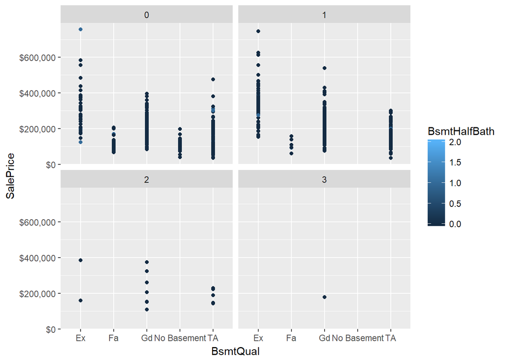

```r
 ggplot(homedf, aes(x = BsmtQual, y = SalePrice, color=BsmtHalfBath)) + geom_point()+
   scale_y_continuous(labels = dollar)+
  facet_wrap(~BsmtFullBath)
```

```r
homedf %>% count(homedf$BsmtFullBath)
```

```
## # A tibble: 4 x 2
##   `homedf$BsmtFullBath`     n
##                   <int> <int>
## 1                     0   856
## 2                     1   588
## 3                     2    15
## 4                     3     1
```

```r
homedf %>% count(homedf$BsmtHalfBath)
```

```
## # A tibble: 3 x 2
##   `homedf$BsmtHalfBath`     n
##                   <int> <int>
## 1                     0  1378
## 2                     1    80
## 3                     2     2
```

# Energy Feature

```r
homedf %>% count(homedf$CentralAir)
```

```
## # A tibble: 2 x 2
##   `homedf$CentralAir`     n
##   <chr>               <int>
## 1 N                      95
## 2 Y                    1365
```

```r
homedf %>% count(homedf$HeatingQC)
```

```
## # A tibble: 5 x 2
##   `homedf$HeatingQC`     n
##   <chr>              <int>
## 1 Ex                   741
## 2 Fa                    49
## 3 Gd                   241
## 4 Po                     1
## 5 TA                   428
```

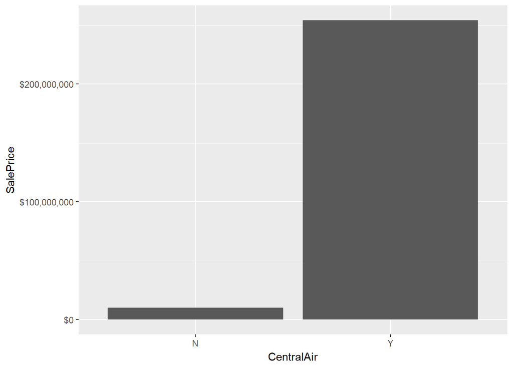

```r
 ggplot(homedf, aes(x = CentralAir, y = SalePrice)) + geom_bar(stat = "identity")+
   scale_y_continuous(labels = dollar)
```

```r
  #facet_wrap(~CentralAir)
```

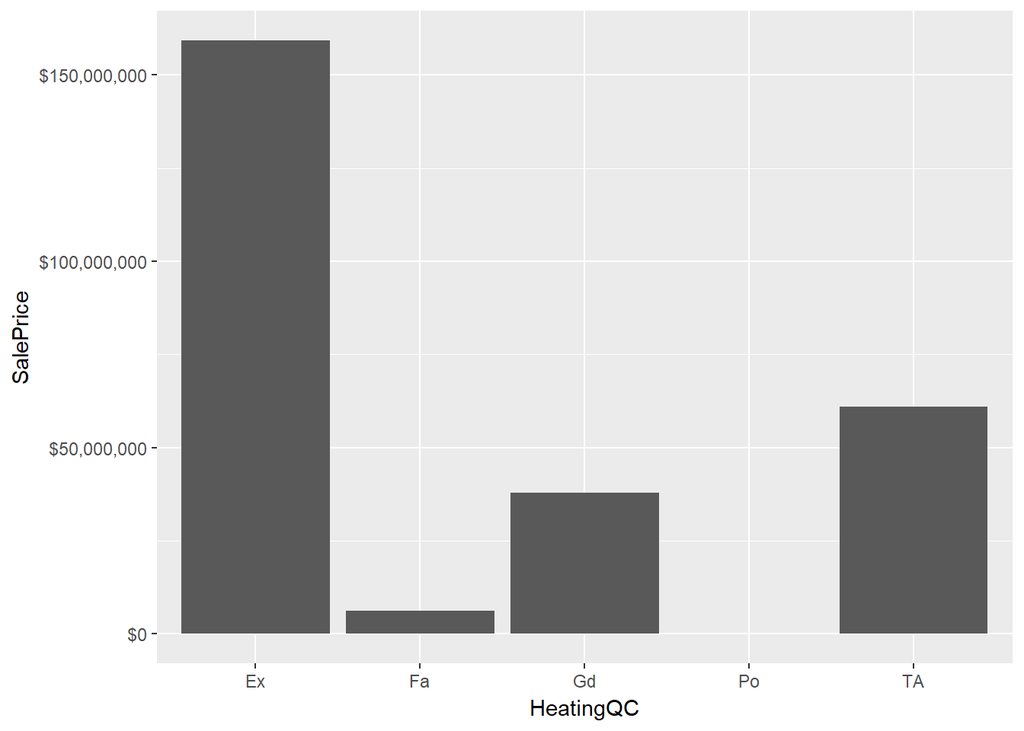

```r
 ggplot(homedf, aes(x = HeatingQC, y = SalePrice)) + geom_bar(stat = "identity")+
   scale_y_continuous(labels = dollar)
```

#Ground level Sqft GrLivArea is the total of fist floor and second floor sqf. There is many Zeros in the X2ndFlrSF.

```r
homedf %>% count(homedf$HouseStyle)
```

```
## # A tibble: 8 x 2
##   `homedf$HouseStyle`     n
##   <chr>               <int>
## 1 1.5Fin                154
## 2 1.5Unf                 14
## 3 1Story                726
## 4 2.5Fin                  8
## 5 2.5Unf                 11
## 6 2Story                445
## 7 SFoyer                 37
## 8 SLvl                   65
```

```r
homedf %>% count(homedf$X2ndFlrSF==0)
```

```
## # A tibble: 2 x 2
##   `homedf$X2ndFlrSF == 0`     n
##   <lgl>                   <int>
## 1 F                         631
## 2 T                         829
```

It looks like 829 homes doesn’t have a second floor.

```r
summary(homedf$GrLivArea)
```

```
##    Min. 1st Qu.  Median    Mean 3rd Qu.    Max.
##     334    1130    1464    1515    1777    5642
```

```r
homedf %>% count(homedf$GrLivArea,BedroomAbvGr)
```

```
## # A tibble: 1,065 x 3
##    `homedf$GrLivArea` BedroomAbvGr     n
##                 <int>        <int> <int>
##  1                334            1     1
##  2                438            1     1
##  3                480            1     1
##  4                520            1     1
##  5                605            2     1
##  6                616            2     1
##  7                630            1     6
##  8                672            2     2
##  9                691            2     1
## 10                693            2     1
## # ... with 1,055 more rows
```

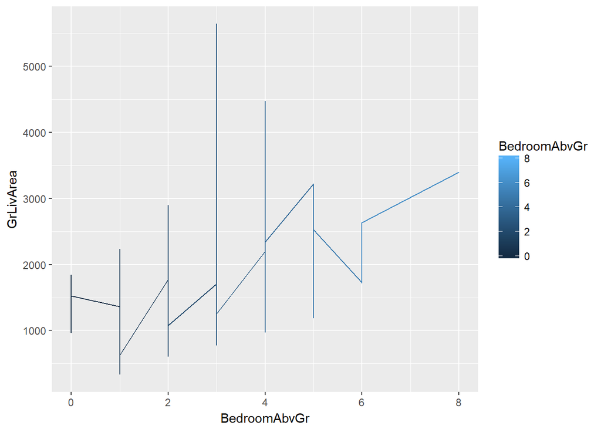

```r
 ggplot(homedf, aes( BedroomAbvGr,GrLivArea,color = BedroomAbvGr)) + geom_line()
```

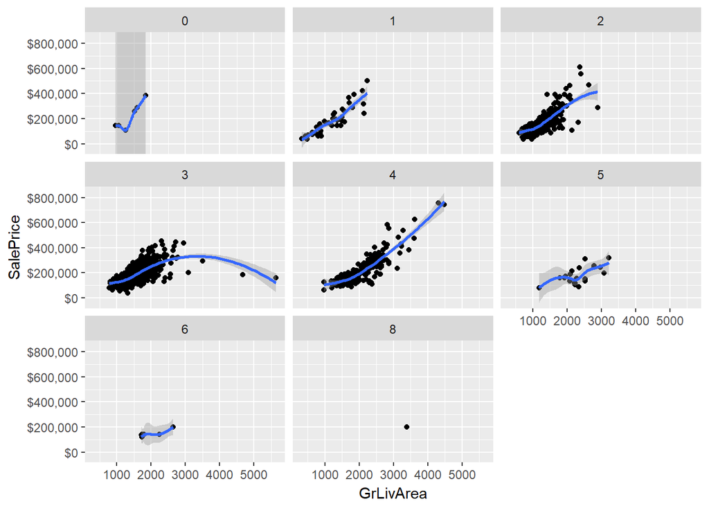

```r
ggplot(homedf, aes(GrLivArea, SalePrice))+
  geom_point()+
  stat_smooth()+
  scale_y_continuous(labels = dollar)+
  facet_wrap(~BedroomAbvGr)
```

The number of bedrooms above ground and ground level living area sqft shows strong corelation with sale price.

# Number of bathrooms and price

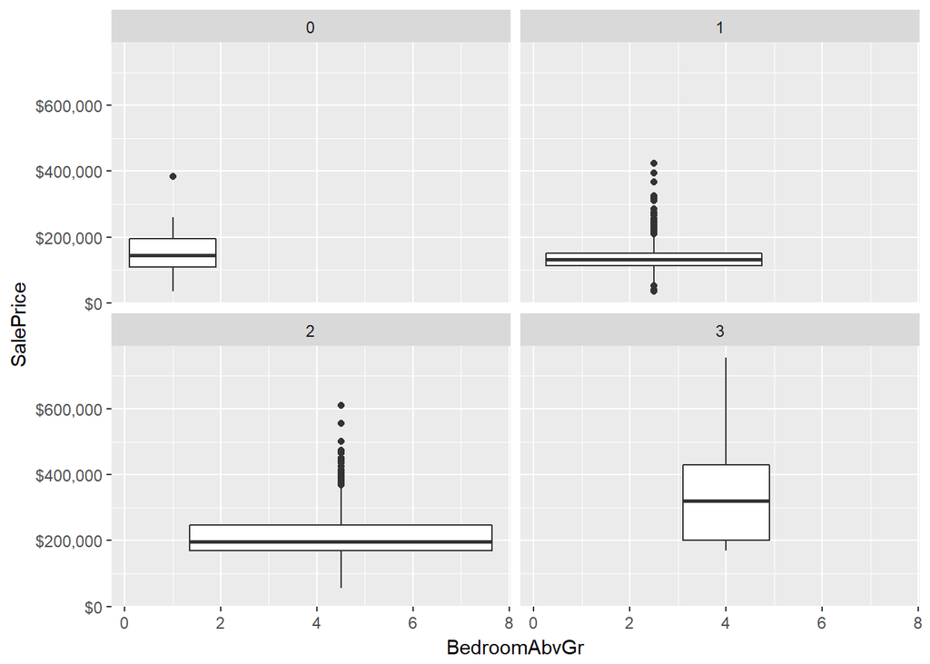

```r
 #ggplot(homedf, aes(x = BedroomAbvGr , y = SalePrice)) + geom_bar(stat = "identity")+
#   scale_y_continuous(labels = dollar)+
ggplot(homedf, aes(x = BedroomAbvGr, y = SalePrice, fill = HalfBath)) +
  geom_boxplot() +
   scale_y_continuous(labels = dollar)+
  facet_wrap(~FullBath)
```

```r
homedf %>% count(homedf$BedroomAbvGr,FullBath,HalfBath,BsmtFullBath == 1)
```

```
## # A tibble: 63 x 5
##    `homedf$BedroomAbvGr` FullBath HalfBath `BsmtFullBath == 1`     n
##                    <int>    <int>    <int> <lgl>               <int>
##  1                     0        0        0 F                       1
##  2                     0        0        0 T                       1
##  3                     0        0        1 F                       2
##  4                     0        0        2 F                       1
##  5                     0        1        1 T                       1
##  6                     1        0        0 T                       1
##  7                     1        0        1 T                       1
##  8                     1        1        0 F                       8
##  9                     1        1        0 T                      21
## 10                     1        1        1 F                       2
## # ... with 53 more rows
```

```r
 homedf%>%
  select(SalePrice, FullBath )
```

```
## # A tibble: 1,460 x 2
##    SalePrice FullBath
##        <int>    <int>
##  1    208500        2
##  2    181500        2
##  3    223500        2
##  4    140000        1
##  5    250000        2
##  6    143000        1
##  7    307000        2
##  8    200000        2
##  9    129900        2
## 10    118000        1
## # ... with 1,450 more rows
```

# Kitchen quality and number of kitchens

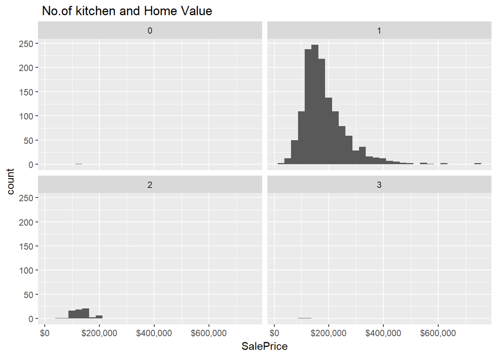

```r
ggplot(homedf, aes(x = SalePrice)) +
  geom_histogram()+
    scale_x_continuous(labels = dollar)+
 facet_wrap(~KitchenAbvGr)+
  ggtitle(" No.of kitchen and Home Value")
```

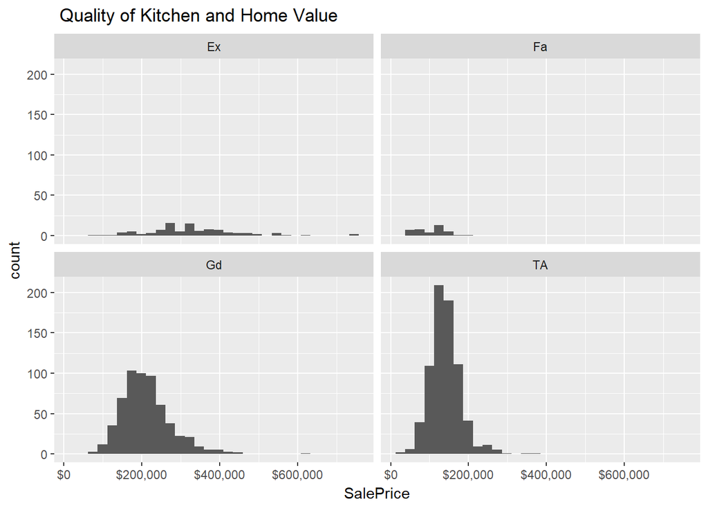

```r
ggplot(homedf, aes(x = SalePrice)) +
  geom_histogram()+
    scale_x_continuous(labels = dollar)+
 facet_wrap(~KitchenQual)+

ggtitle( " Quality of Kitchen and Home Value ")
```

The quality of kitchen increases the value of home. The number kitchen is not so much.

# Home Functionality

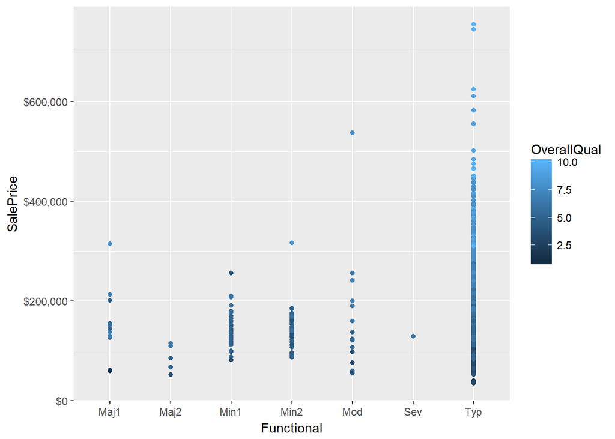

```r
ggplot (homedf,aes(Functional,SalePrice,color= OverallQual))+
  geom_point()+
  scale_y_continuous(labels = dollar)+
   geom_smooth()
```

The Market value of a home with typical functionality is higher than the others. Functionality and over all quality of home is corelated.